# Introductory Statistics with Randomization and Simulation: Chapter 5

## \(R^2\)

- The strength of the fit of a linear model is most commonly evaluated using \(R^2\)
- \(R^2\) is calculated as the square of the correlation coefficient
- It tells us what percentage of the variability in the response variable is explained by the model

## \(R^2\)

- The strength of the fit of a linear model is most commonly evaluated using \(R^2\)
- \(R^2\) is calculated as the square of the correlation coefficient
- It tells us what percentage of the variability in the response variable is explained by the model
- The remainder of the variability is explained either by variables not included in the model (not known!), or by inherent randomness of the data

## \(R^2\)

- The strength of the fit of a linear model is most commonly evaluated using \(R^2\)
- \(R^2\) is calculated as the square of the correlation coefficient
- It tells us what percentage of the variability in the response variable is explained by the model
- The remainder of the variability is explained either by variables not included in the model (not known!), or by inherent randomness of the data
- For the model we've been working with, \(R^2 = (-0.62)^2 = 0.38\)

## Interpretation of \(R^2\)

Which of the below is the correct interpretation of \(R = -0.62, R^2 = 0.38\)

- 38% of the variability in the % of HG graduates among the 51 states is explained by the model.
- 38% of the variability in the % of residents living in poverty among the 51 states is explained by the model.
- 38% of the time % HS graduates predict % living in poverty correctly.
- 62% of the variability in the % of residents living in poverty among the 51 states is explained by the model.

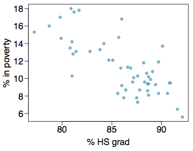

## Interpretation of \(R^2\)

Which of the below is the correct interpretation of \(R = -0.62, R^2 = 0.38\)

- 38% of the variability in the % of HG graduates among the 51 states is explained by the model.
- **38% of the variability in the % of residents living in poverty among the 51 states is explained by the model.**
- 38% of the time % HS graduates predict % living in poverty correctly.
- 62% of the variability in the % of residents living in poverty among the 51 states is explained by the model.

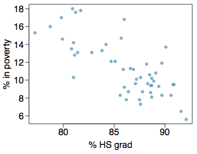

## Poverty versus Region (East, West)

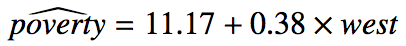

- Explanatory variable: region, *reference level*: east
- **Intercept**: the estimated average poverty percentage in the eastern states is 11.17%
  - This is the value we get if we plug in \(0\) for the explanatory variable

## Poverty versus Region (East, West)

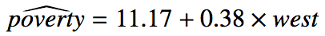

- Explanatory variable: region, *reference level*: east
- **Intercept**: the estimated average poverty percentage in the eastern states is 11.17%
  - This is the value we get if we plug in \(0\) for the explanatory variable
- **Slope**: the estimated average poverty percentage in western states is 0.38% higher than in eastern states
  - The estimated average poverty percentage in western states is \(11.17 + 0.38 = 11.55%\).
  - This is the value we get if we plug in \(1\) for the explanatory variable

## Poverty versus Region (northeast, midwest, west, south)

Which region (northeast, midwest, west or south) is the reference level?

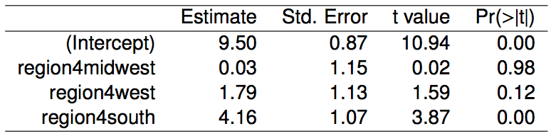

- northeast
- midwest
- west
- south
- cannot tell

## Poverty versus Region (northeast, midwest, west, south)

Which region (northeast, midwest, west or south) is the reference level?

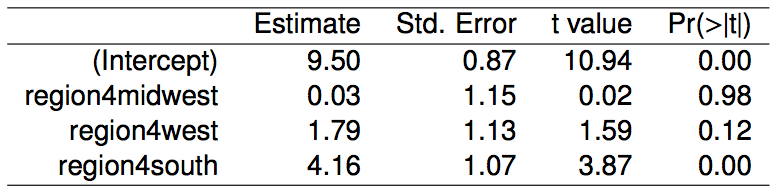

- **northeast**
- midwest
- west
- south
- cannot tell